## Introduction

One thing that people regularly do is quantify how much of a particular activity they do, but they rarely quantify how well they do it. In this project, we use data from accelerometers on the belt, forearm, arm, and dumbell of 6 participants. The goal of this project is to predict the manner in which they did the exercise. This is the “classe” variable in the training set.

# Data preparation

Now, let’s start with loading the training data.

```r
## Read-in training data
trainingdata1 <- read.csv("pml-training.csv", na.strings=c("", "NA", "NULL", " "))
```

We will remove all columns with NA values in them.

```r
## Remove predictor variables with NA values
trainingdata2 <- trainingdata1[ , colSums(is.na(trainingdata1)) == 0]
```

This reduces the number of variables from 160 to 60. The next step in the data preprocessing is the removal of variables that we know are not related to the dependent variable.

```r
## Remove variables that are useless for predicting
remove <- c('X', 'user_name', 'raw_timestamp_part_1', 'raw_timestamp_part_2', 'cvtd_timestamp', 'new_window', 'num_window')
trainingdata3 <- trainingdata2[, -which(names(trainingdata2) %in% remove)]
```

This reduces the number of variables from 60 to 53. Further reduction of the number of variables can be done based on their correlations. To investigate this, we can show a plot of the correlations.

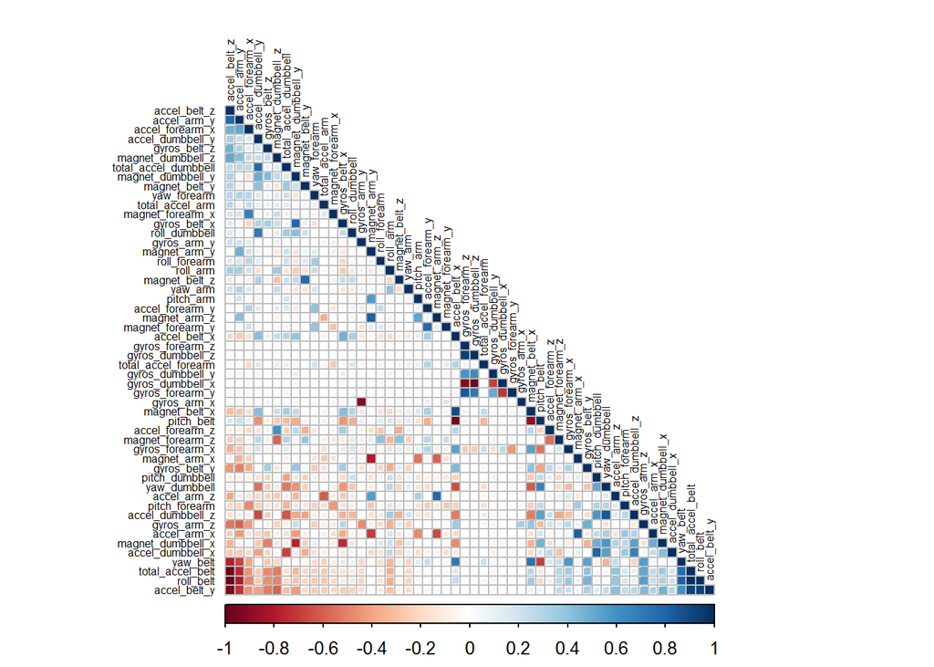

```r
## Correlation plot
corMatrix <- cor(trainingdata3[sapply(trainingdata3, is.numeric)])
corrplot(corMatrix, order = "FPC", method = "square", type = "lower", tl.cex = 0.5, tl.col = rgb(0, 0, 0))
```

In the last step, We will perform PCA with a treshold of 0.99 to further reduce the number of variables. This reduces the total number of variables from 53 to 37.

```r
## Perform PCA to further reduce training data
preProc <- preProcess(trainingdata3[sapply(trainingdata3, is.numeric)], method = "pca", thresh = 0.99)
trainingdata4 <- predict(preProc, trainingdata3)
```

## Data partioning

In this phase, the dataset will be split in a training and testing set.

```r
# Create a train and test set
inTrain <- createDataPartition(y=trainingdata4$classe, p=0.7, list=FALSE)
training <- trainingdata4[inTrain,]
testing <- trainingdata4[-inTrain,]
```

We use a random forest as the model to perform the prediction. The accuracy of the model is

```r
# Train the model
ModelFit <- randomForest(classe~., data=training, ntree=100, importance=TRUE)

# Make a prediction
PredictionModel <- predict(ModelFit, testing)
Accuracy <- postResample(testing$classe, PredictionModel)
Accuracy
```

```
##  Accuracy     Kappa
## 0.9743415 0.9675275
```

It can be seen that the accuracy is around 97%, which is good.

## Model prediction

First, we read in the validation data set on which we want to use the model. The same preprocessing steps as for the training set are performed.

```r
#Read-in validation data
validationdata1 <- read.csv("pml-testing.csv", na.strings=c("", "NA", "NULL", " "))
validationdata2 <- validationdata1[ , colSums(is.na(validationdata1)) == 0]
validationdata3 <- validationdata2[, -which(names(validationdata2) %in% remove)]
validationdata4 <- predict(preProc, validationdata3)
```

The last step is making the actual prediction for the 20 cases. The output can be seen below:

```r
prediction <- predict(ModelFit, validationdata4)

prediction
```

```
##  1  2  3  4  5  6  7  8  9 10 11 12 13 14 15 16 17 18 19 20
##  B  A  B  A  A  E  D  B  A  A  B  C  B  A  E  E  A  B  B  B
## Levels: A B C D E
```